# P337: Correlation of gene modules with donor outcomes

Kim Dill-McFarland, kadm@uw.edu

version August 01, 2023

# Background

The purpose of this workflow is to determine which (if any) BAL and/or BE genes can predict eosinophils recruitment upon allergen challenge

# Setup

Load packages

```r
# Data manipulation and figures
library(tidyverse)
library(tidytext)
# RNAseq data
library(limma)
#Correlation
library(corrplot)
#PLS
library(mixOmics)
##  Be careful of version as this package is often not back compatible
#Enrichment MSigDB
# library(SEARchways)
# Print pretty table to knit file
library(knitr)
library(kableExtra)
options(knitr.kable.NA = '')

`%notin%` <- Negate(`%in%`)
```

Set seed

```r
set.seed(4389)
```

# Data

## Load data

```r
attach("data_clean/P337_BAL_data.RData")
attach("data_clean/P337_BE_data.RData")
attach("results/model_fitting.RData")
```

## Format data

Select pre (V4) samples from donors with both BAL and BE samples

```r
samps <- intersect(dat.BAL.abund.norm.voom$targets$donorID,
                   dat.BE.abund.norm.voom$targets$donorID)

targets.all <- dat.BAL.abund.norm.voom$targets %>%
  bind_rows(dat.BE.abund.norm.voom$targets) %>%
  filter(visit=="V4" & donorID %in% samps)
```

Select genes associated with eosinophils.

```r
bal.eos <- lm_eos_BAL$lm %>%
  filter(variable=="EOS.pct" & FDR < 0.1) %>%
  mutate(gene = paste0("BAL_",gene)) %>%
  pull(gene)
be.eos <- lm_eos_BE$lm %>%
  filter(variable=="EOS.pct" & FDR < 0.1) %>%
  mutate(gene = paste0("BE_",gene)) %>%
  pull(gene)

E.bal <- as.data.frame(dat.BAL.abund.norm.voom$E) %>%
  rownames_to_column() %>%
  mutate(rowname=paste0("BAL_",rowname)) %>%
  pivot_longer(-rowname, names_to = "libID") %>%
  inner_join(targets.all) %>%
  dplyr::select(donorID, rowname, value) %>%
  pivot_wider(names_from = donorID)
E.be <- as.data.frame(dat.BE.abund.norm.voom$E) %>%
  rownames_to_column() %>%
  mutate(rowname=paste0("BE_",rowname)) %>%
  pivot_longer(-rowname, names_to = "libID") %>%
  inner_join(targets.all) %>%
  dplyr::select(donorID, rowname, value) %>%
  pivot_wider(names_from = donorID)
E.all <- bind_rows(E.bal, E.be) %>%
  filter(rowname %in% c(bal.eos,be.eos)) %>%
  column_to_rownames() %>%
  t() %>% as.data.frame() %>%
  rownames_to_column() %>%
  arrange(rowname) %>%
  column_to_rownames() %>%
  as.matrix()
```

# Partial least squares (PLS)

Regression mode: Y variable is deflated with respect to information extracted/modeled from local regression on X. Here, the goal is to predict Y from X (and vice versa).

Sparse: simultaneous variable selection in X and Y with LASSO penalization on each pair of loading vectors

http://mixomics.org/methods/spls/

Format data

```r
X <- E.all[complete.cases(E.all),]

Y <- dat.BAL.abund.norm.voom$targets %>%
  filter(visit=="V5" & donorID %in% rownames(X)) %>%
  rownames_to_column() %>%
  dplyr::select(donorID, EOS.pct) %>%
  arrange(donorID) %>%
  column_to_rownames("donorID")

##Check order
identical(rownames(X),rownames(Y))
```

```
## [1] TRUE
```

```r
save(X,Y, file = "results/PLS/PLS_data.RData")
```

Perform PLS regression.

```r
ncomp = 10
#PLS
pls_result <- pls(X, Y, ncomp = ncomp, mode = "regression")
#SPLS
# spls_result <- spls(X, Y, ncomp = ncomp, mode = "regression")
```

### Tuning

#### Number of components

Compute evaluation criteria for (s)PLS.

```r
pls.Q2 <- perf(pls_result, validation = "Mfold",
               folds = 10, nrepeat = 5,
                progressBar = FALSE)
save(pls.Q2, file="results/PLS/pls.Q2.RData")
```

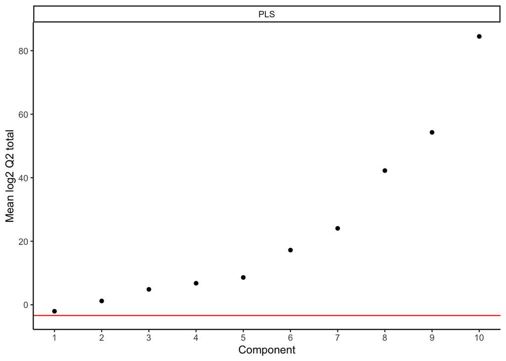

Thus, axis loadings will be assessed as well. Looking at the axis loadings, component 1 explains the most variation (~13%) followed by component 4 (~12%). All other components contribute to a lesser extent (<10%).

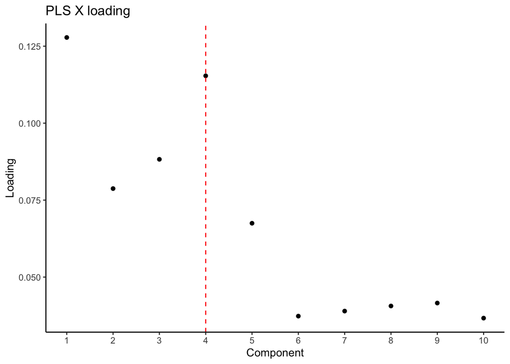

Taken together, 4 X components will be assessed, though likely only 1 component will be used in the final model.

#### Number of X variables

Compute error and fit metrics for X variables on each component. The goal is to minimize error while maximizing correlation.

- mean average error (MAE): average magnitude of absolute model error
- R2: correlation between predictions and observations

Tuning suggests less than 20 features should be selected on component 1. Component 2 did not reach a minimum MAE as its values were still decreasing at the maximum number of features tested. Components 3 and 4 don’t appear to improve the model.

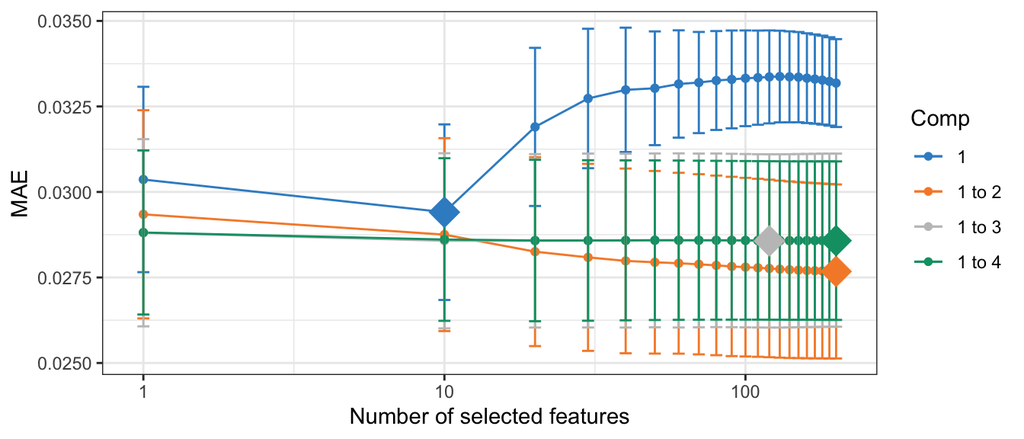

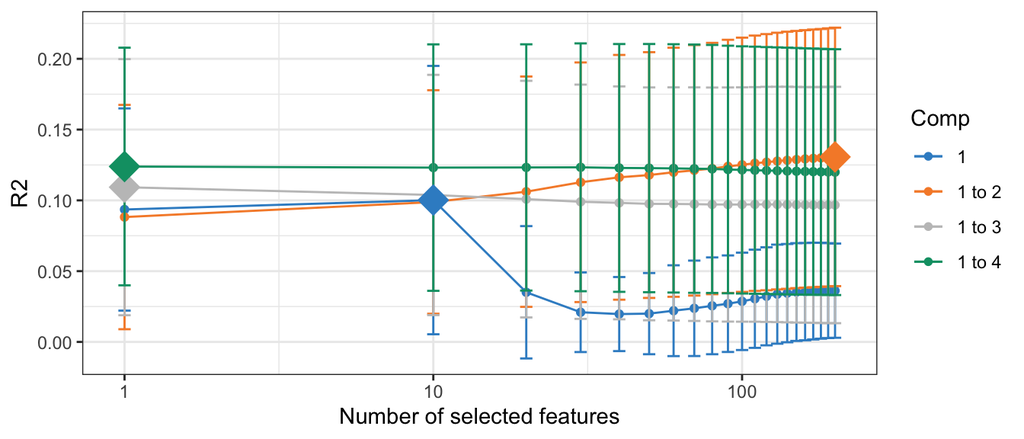

Test 1 to 20 features in more detail.

Zooming in, we see that that the component 1 correlation suggested number of variables is 4 and MAE suggested is 4.

Component 2 does not improve MAE or R2 when 1 feature is used. Given this and the lack of maximum R2 or minimum MAE achieved, we will tune the final model on 1 component.

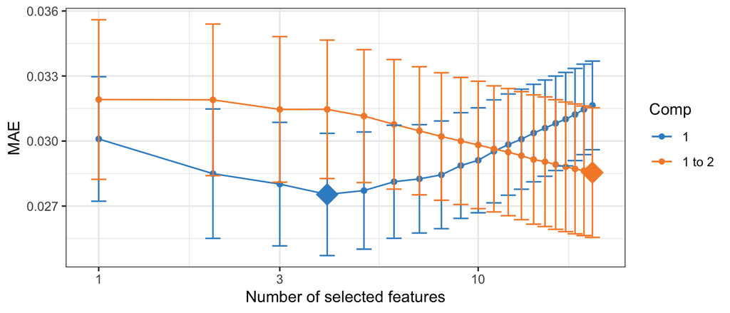

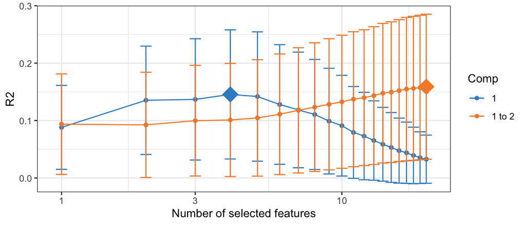

### Run PLS

Using the parameters determined above, run the final PLS regression.

```r
choice.ncomp <- pls.zoom.MAE.X$choice.ncomp$ncomp
choice.keepX <- pls.zoom.MAE.X$choice.keepX[1:choice.ncomp]

spls.tuned <- spls(X,Y,
                 keepX = choice.keepX,
                 keepY = 1,
                 ncomp = choice.ncomp,
                 mode = "regression")

#Save
save(spls.tuned, file="results/PLS/SPLS.RData")
```

This results in the following variables..

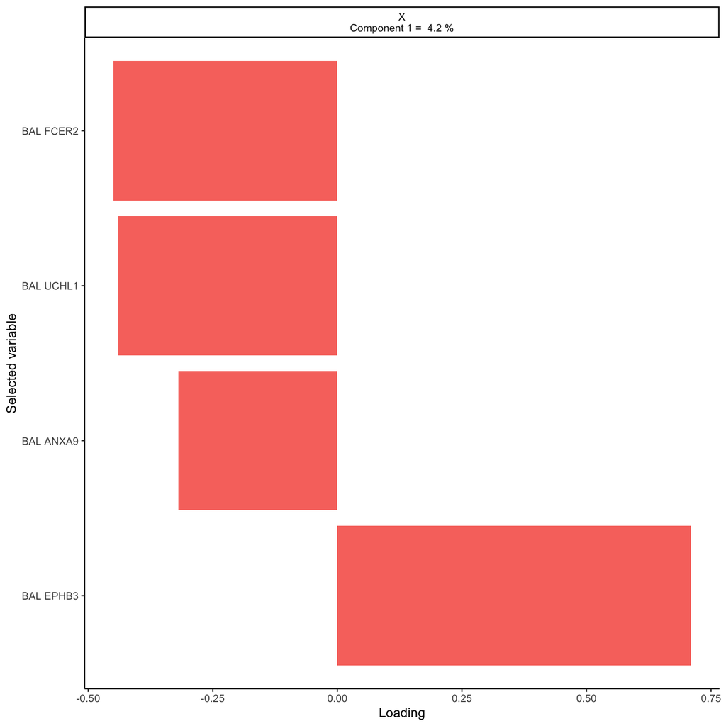

Correlations within PLS

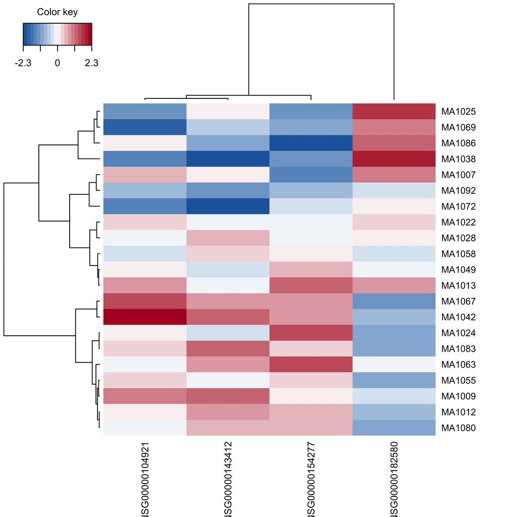

Correlation of PCs

| x |
| --- |
| 0.8496296 |